# Numpy

### Numpy is basically a core library for scientific calculations in Python. It provides a high performance object of multi-dimensional array and various tools for working with these arrays, tools for working with C,C++. It is also used for computing Linear Algebra, Fourier Transform and random number capabilities. Numpy can also be used as an efficient multi-dimensional container for data.

### Examples of Numpy

```python
#An example that prints a simple array.

import numpy as np
array=np.array([3,4,15,17,12])
print(array)
```

```
[ 3  4 15 17 12]
```

```python
#An example that prints a multi-dimensional array

import numpy as np
array=np.array([(1,2,3),(4,5,6)])
print(array)
```

```
[[1 2 3]
 [4 5 6]]
```

### EXPLANATION

#### In the above two examples, we have demonstrated one-dimensional and multi-dimensional arrays. In order to do this, we have imported the numpy library and from that library, we have used the array function ie. np.array() to create the arrays.

```python
#An example that prints an array of complex numbers.

import numpy as np
cnum=np.array([1,2,3], dtype=complex)
print(cnum)
```

```
[1.+0.j 2.+0.j 3.+0.j]
```

```python
#An example that demonstrates conversion of list to array.

import numpy as np
l =[1,2,3,4,5,6,7]  #list
a=np.array(l)
print([a])
```

```
[array([1, 2, 3, 4, 5, 6, 7])]
```

### EXPLANATION

#### In above two examples we have demonstrated the creation of array with complex numbers and the other example demonstrates the conversion of list in array using numpy array() function.

```python
#An example to demonstrate the use of  numpy generation function

import numpy as np
z=np.linspace(0,5,5)
print(z)

y=np.arange(3,7,0.5)
print(y)
```

```
[0.   1.25 2.5  3.75 5.  ]
[3.  3.5 4.  4.5 5.  5.5 6.  6.5]
```

### EXPLANATION

#### In the abve example we have demonstrated the use of numpy generation function linspace() and arange() which creates a array with sequence which are evenly placed.

```python
#An example to demonstrate the arrange function and its data type declaration.

import numpy as np
c=np.arange(5)
print(c)
c[1]=9.7
print(c)  #int type so 9 is added instead of 9.7

c=np.arange(5.) # . signifies float data type
print(c)
c[1]=9.7
print(c)  #5. float  type so 9.7 is added
```

```
[0 1 2 3 4]
[0 9 2 3 4]
[0. 1. 2. 3. 4.]
[0.  9.7 2.  3.  4. ]
```

### EXPLANATION

#### In the above example we have demonstrated the arrange function and also how to declare int and float data type and updation of array with same data type. And what value it takes when a updation with different data type is performed.

```python
#An example to demonstrate a math function a numpy array

import numpy as np
a=np.arange(1,4)
b=np.arange(4,7)
print(a)
print(b)
c=a+b
print(c) #sum of a and b
```

```
[1 2 3]
[4 5 6]
[5 7 9]
```

### EXPLANATION

#### In the above example we have created two arrays with arange() and demonstrated the math function of adding both the arrays and storing the result in different array and same is given as output

```python
#An example that demonstrates shape and re-shape attributes.

import numpy as np
array1=np.array([[1,2,3],[4,5,6]])
print ("The dimension of the array is :",array1.shape)
```

```
The dimension of the array is : (2, 3)
```

### EXPLANATION

#### The above example demostrates shape attribute which gives the dimension of the array as output.

```python
#An example that demonstrates shape and re-shape attributes.

import numpy as np
array2=np.array([[1,2,3],[4,5,6]])
print("Original array :"+'\n',array2)
array2.shape=(3,2)
print("New array :"+'\n',array2)
```

```
Original array :
 [[1 2 3]
 [4 5 6]]
New array :
 [[1 2]
 [3 4]
 [5 6]]
```

### EXPLANATION

#### The above example demonstrate the changing of dimension of arrays from a (2,3) array to (3,2) array.

```python
#An example that demonstrates the slicing on the array.

import numpy as np
array=np.arange(30)
print(array)
print("The Sliced array is :",array[12:24])
print("The Sliced array is :",array[:24])
print("The Sliced array is :",array[24:])
```

```
[ 0  1  2  3  4  5  6  7  8  9 10 11 12 13 14 15 16 17 18 19 20 21 22 23
 24 25 26 27 28 29]
The Sliced array is : [12 13 14 15 16 17 18 19 20 21 22 23]
The Sliced array is : [ 0  1  2  3  4  5  6  7  8  9 10 11 12 13 14 15 16 17 18 19 20 21 22 23]
The Sliced array is : [24 25 26 27 28 29]
```

### EXPLANATION

#### In the above example, we have created the array of range 30 and sliced array from 12-24 and also we have used slicing to slice array upto 24 using array[:24] and after 24 using array[24:] and output is given as above.

```python
#Example to demonstrate slicing of columns and rows in arrays.

# Original Array
import numpy as np
array = np.array([[1,2,3],[4,5,6],[7,8,9]])
print ('Original Array => '+'\n',array)


# Array of items in the second column
print ('The items in the second column are =>'+'\n',array[...,1])


# Slicing of all items from the second row
print ('The items in the second row are =>'+'\n',array[1,...])


# Slicing of  all items from column 1 onwards
print ('The items column 1 onwards are =>'+'\n',array[...,1:])
```

```
Original Array =>
 [[1 2 3]
 [4 5 6]
 [7 8 9]]
The items in the second column are =>
 [2 5 8]
The items in the second row are =>
 [4 5 6]
The items column 1 onwards are =>
 [[2 3]
 [5 6]
 [8 9]]
```

### EXPLANATION

#### In the above example, we have demonstrated slicing on an array. Firstly, we have declared an array of dimensions 3 x 3. Then, we have sliced the second column of the array and lastly, we have sliced all items from the array right from column one. The output is as shown.

```python
#An example that demonstrates Integer Indexing on an array.

import numpy as np
array = np.array([[1,2,3],[4,5,6],[7,8,9]])
print ('Original Array => '+'\n',array)
a=array[[0,1,2],[2,1,0]]
print("The elements on the diagonal of the array are :",a)
```

```
Original Array =>
 [[1 2 3]
 [4 5 6]
 [7 8 9]]
The elements on the diagonal of the array are : [3 5 7]
```

### EXPLANATION

#### The goal of the above example is to demonstrate Integer indexing on the array. To achieve this goal, we declare an array of dimensions 3 x 3. One element of specified column from each row of the array object is selected. Hence, the row index contains all row numbers, and the column index specifies the element to be selected. Here [0,1,2] and [2,1,0] indicate the elements at positions (0,2),(1,1) and (2,0) respectively. The output is as shown above

```python
#An example that demonstrates Integer Indexing on an array.

import numpy as np
array = np.array([[1,2,3],[4,5,6],[7,8,9]])
print ('Original Array => '+'\n',array)

rows = np.array([[0,0],[2,2]])
cols = np.array([[0,2],[0,2]])
y    = array[rows,cols]

print ("The Corner elements of the array are =>"'\n',y)
```

```
Original Array =>
 [[1 2 3]
 [4 5 6]
 [7 8 9]]
The Corner elements of the array are =>
 [[1 3]
 [7 9]]
```

### EXPLANATION

#### In the above example, we have demonstrated the indexing on the array of dimensions 3 x 3. The goal of this example is to print the elements on the corners. To achieve this, elements placed at corners of the array are selected. The row indices of selection are [0,0] and [2,2] whereas the column indices are [0,2] and [0,2]. The result is as shown above.

# Scipy

### Scipy is an add-on to Python which gives access to large and vast array of numerical functions for scientific computing. Scipy is the collection of mathematical algorithms and functions built on Numpy data structures. Scipy is organized into subpackages covering different scientific computing areas. It is a data-processing and prototyping environment rivaling MATLAB.

```python
#An example that demonstrates integration of a function.

import scipy.integrate
res, err=scipy.integrate.quad(lambda x: x**3,2,6)
print("Integration of x to the power 2 is => ",res)
```

```
Integration of x to the power 2 is =>  320.0
```

```python
#An example that demonstrates integration of a function.

import scipy.integrate
res, err=scipy.integrate.quad(lambda x: x**3,0.,8)
print(res)
```

```
1024.0
```

### EXPLANATION

#### The above two examples demonstrate the integration of a function. The quad() function is used to carry out integration operation on a given function. It is present in the Scipy library.

```python
#An example that demonstrates linear algebraic functions to calculate inverse of a matrix using scipy library

import numpy as np
import scipy.linalg
array = np.array([[1,2,3],[0,1,4],[5,6,0]])
scipy.linalg.inv(array)
```

```
array([[-24.,  18.,   5.],
       [ 20., -15.,  -4.],
       [ -5.,   4.,   1.]])
```

### EXPLANATION

#### In the above example, we have demonstrated an example of linear algebra module from scipy. Firstly, we have imported numpy and used it to create a 3 x 3 matrix. Now we use the inverse function in the linear algebra from the scipy library to calculate the inverse of the matrix. The output is as shown above

```python
#An example that demonstrates linear algebraic functions on complex numbers using scipy library.
import numpy as np
import scipy.linalg
array = np.array([[1,2,3],[0,1,4],[5,6,0]])
scipy.linalg.eigvals(array)
```

```
array([-5.2296696 +0.j, -0.02635282+0.j,  7.25602242+0.j])
```

### EXPLANATION

#### In the above example, we have demonstrated an example of linear algebra module from scipy. Firstly, we have imported numpy and used it to create a 3 x 3 matrix. Now we use the eigvals function in the linear algebra from the scipy library to calculate the complex functions. The output is as shown above.

```python
#An example that demonstrates interpolation of values.

import numpy as np
from scipy import interpolate, integrate
varA=np.arange(2,15)
varB=np.exp(-varA/3.0)
varC=interpolate.interp1d(varA,varB)
integrate.simps(varB[1:-1],varA[1:-1])
```

```
1.0643391779018567
```

### EXPLANATION

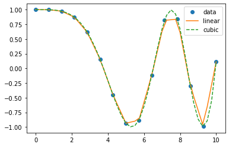

```python
#An example that demonstrates 1-D Interpolation.

from scipy.interpolate import interp1d

x = np.linspace(0, 10, num=15, endpoint=True)
y = np.cos(-x**2/9.0)
f = interp1d(x, y)
f2 = interp1d(x, y, kind='cubic')

xnew = np.linspace(0, 10, num=41, endpoint=True)
import matplotlib.pyplot as plt
plt.plot(x, y, 'o', xnew, f(xnew), '-', xnew, f2(xnew), '--')
plt.legend(['data', 'linear', 'cubic'], loc='best')
plt.show()
```

### EXPLANATION

#### The interp1d class in scipy.interpolate is a convenient method to create a function based on fixed data points which can be evaluated anywhere within the domain defined by the given data using linear interpolation. An instance of this class is created by passing the 1-d vectors comprising the data. The instance of this class defines a call method and can therefore by treated like a function which interpolates between known data values to obtain unknown values. Behavior at the boundary can be specified at instantiation time.

```python
#An example that demonstrates fourier transform.

import numpy as np
from scipy.fftpack import fft, ifft
x = np.array([11, 12, 13, 14, 15]) # declaring an array of 5 values
y = fft(x)
print("Fast fourier transform of array x:")
print(y) #fast fourier transform of array x
```

```
Fast fourier transform of array x:
[65. +0.j         -2.5+3.4409548j  -2.5+0.81229924j -2.5-0.81229924j
 -2.5-3.4409548j ]
```

### EXPLANATION

#### In the above example, the goal is to perform fourier transform on an array. Using numpy library, we declare an array of 5 elements. The fftpack in the scipy library contains the functions for the fourier transform. We use fft() to carry out the Fourier transform on the array.

```python
#Example to demonstrate linear algebraic function to find the deteminant of the matrix

import numpy as np
import scipy.linalg
array = np.array([[1,2,3],[0,1,4],[5,6,0]])
scipy.linalg.det(array)
```

```
0.9999999999999987
```

### EXPLANATION

#### In the above example, we have demonstrated an example of linear algebra module from scipy. Firstly, we have imported numpy and used it to create a 3 x 3 matrix. Now we use the det() function in the linear algebra from the scipy library to calculate the Determinant of the matrix. The output is as shown above.

```python
#Example to demonstrate the creation of polynomials using array in scipy

from numpy import poly1d
a=np.array([2,6,3])
p = poly1d(a)
print(p)
```

```
   2
2 x + 6 x + 3
```

## References

### https://www.tutorialspoint.com/numpy/index.htm

### https://docs.scipy.org/doc/scipy-0.18.1/reference/index.html